# Final practice

```r
# 1. Convert 'City' to a categorical variable (One-Hot Encoding)
dataset_land_cleaned <- dataset_land_cleaned %>%
  mutate(City = as.numeric(as.factor(City)))  # Ensure 'City' is treated as a categorical variable

summary(dataset_land_cleaned)
```

```
##      Price            District         City
##  Min.   :  4900   Porto   :3194   Min.   :  1.0
##  1st Qu.: 32500   Lisboa  :2300   1st Qu.: 69.0
##  Median : 55000   Braga   :2127   Median :120.0
##  Mean   : 70482   Aveiro  :1988   Mean   :130.2
##  3rd Qu.: 90000   Santarém:1848   3rd Qu.:202.0
##  Max.   :272500   Leiria  :1804   Max.   :259.0
##                   (Other) :7364
##                              Town              Type
##  São João das Lampas e Terrugem:  239   Land     :20625
##  Pombal                        :  143   Apartment:    0
##  Palmela                       :  120   Building :    0
##  Castelo (Sesimbra)            :  116   Duplex   :    0
##  Charneca de Caparica e Sobreda:  113   Estate   :    0
##  Quinta do Anjo                :  113   Farm     :    0
##  (Other)                       :19781   (Other)  :    0
##       EnergyCertificate    Parking    TotalArea    NumberOfBathrooms
##  No Certificate:20526   Min.   :0   Min.   :  56   Min.   :0
##  A+            :   27   1st Qu.:0   1st Qu.: 600   1st Qu.:0
##  G             :   26   Median :0   Median :1600   Median :0
##  A             :   20   Mean   :0   Mean   :1863   Mean   :0
##  B             :   11   3rd Qu.:0   3rd Qu.:2000   3rd Qu.:0
##  E             :    6   Max.   :0   Max.   :8400   Max.   :0
##  (Other)       :    9
##  CombinedElevator Predicted_Price_Poly Predicted_Price_Expo
##  False:20597      Min.   :60559        Min.   :43004
##  True :   28      1st Qu.:67531        1st Qu.:49815
##                   Median :71505        Median :52423
##                   Mean   :70482        Mean   :52692
##                   3rd Qu.:73881        3rd Qu.:55580
##                   Max.   :81820        Max.   :59973
##
##  Predicted_Price_Power
##  Min.   :61925
##  1st Qu.:67207
##  Median :70260
##  Mean   :70482
##  3rd Qu.:74002
##  Max.   :79978
##
```

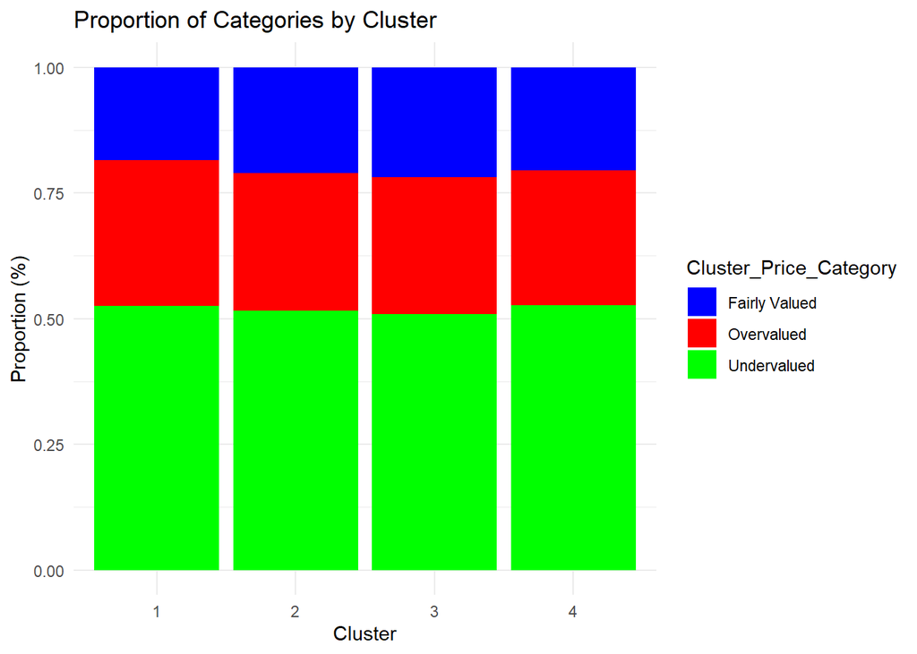

```r
# 2. Exponential Predictive Model
# Using 'TotalArea' and 'City' as predictors, with the log-transformed 'Price' for the exponential model
price_model_expo <- lm(log(Price) ~ TotalArea + City, data = dataset_land_cleaned)

# 3. Prediction and residual calculation
dataset_land_cleaned <- dataset_land_cleaned %>%
  mutate(
    Predicted_Price = exp(predict(price_model_expo, dataset_land_cleaned)),  # Applying exp to get predicted price
    Predicted_Error = Price - Predicted_Price, # Residuals (difference between actual and predicted price)
    Lower_Bound = Predicted_Price - 1.96 * sd(Predicted_Error), # Lower bound for confidence intervals
    Upper_Bound = Predicted_Price + 1.96 * sd(Predicted_Error)  # Upper bound for confidence intervals
  )

# 4. Refine undervaluation definition using confidence intervals
dataset_land_cleaned <- dataset_land_cleaned %>%
  mutate(
    Price_Category = case_when(
      Price < Lower_Bound ~ "Undervalued",
      Price > Upper_Bound ~ "Overvalued",
      TRUE ~ "Fairly Valued"
    )
  )

# 5. Compare actual and predicted prices using ratios
dataset_land_cleaned <- dataset_land_cleaned %>%
  mutate(
    Price_Ratio = Price / Predicted_Price,
    Refined_Price_Category = case_when(
      Price_Ratio < 0.8 ~ "Undervalued",
      Price_Ratio > 1.2 ~ "Overvalued",
      TRUE ~ "Fairly Valued"
    )
  )

# 6. Clustering analysis by similar characteristics
cluster_data <- dataset_land_cleaned %>%
  select(TotalArea, City) %>%
  scale()  # Standardize data before clustering

set.seed(123)
kmeans_result <- kmeans(cluster_data, centers = 4)

# Add clusters to the main dataset
dataset_land_cleaned <- dataset_land_cleaned %>%
  mutate(Cluster = kmeans_result$cluster)

# Calculate average prices by cluster
cluster_summary <- dataset_land_cleaned %>%
  group_by(Cluster) %>%
  summarise(
    Avg_Price = mean(Price, na.rm = TRUE),
    Avg_Predicted = mean(Predicted_Price, na.rm = TRUE)
  )

# Ensure correct merging of summary with the main dataset
dataset_land_cleaned <- dataset_land_cleaned %>%
  left_join(cluster_summary, by = "Cluster")

# Validate that the necessary columns are present
if (!"Avg_Price" %in% names(dataset_land_cleaned)) {
  stop("Error: 'Avg_Price' was not correctly added to the main dataset.")
}

# Identify undervalued apartments by cluster
dataset_land_cleaned <- dataset_land_cleaned %>%
  mutate(
    Cluster_Price_Category = case_when(
      Price < 0.8 * Avg_Price ~ "Undervalued",
      Price > 1.2 * Avg_Price ~ "Overvalued",
      TRUE ~ "Fairly Valued"
    )
  )

# 7. Visualizations
# Bar plot for distribution of categories by cluster
dataset_land_cleaned %>%
  group_by(Cluster, Cluster_Price_Category) %>%
  summarise(Count = n()) %>%
  mutate(Percentage = Count / sum(Count) * 100) %>%
  ggplot(aes(x = as.factor(Cluster), y = Percentage, fill = Cluster_Price_Category)) +
  geom_bar(stat = "identity", position = "fill") +
  ggtitle("Proportion of Categories by Cluster") +
  xlab("Cluster") +
  ylab("Proportion (%)") +
  theme_minimal() +
  scale_fill_manual(values = c("blue", "red", "green"))
```

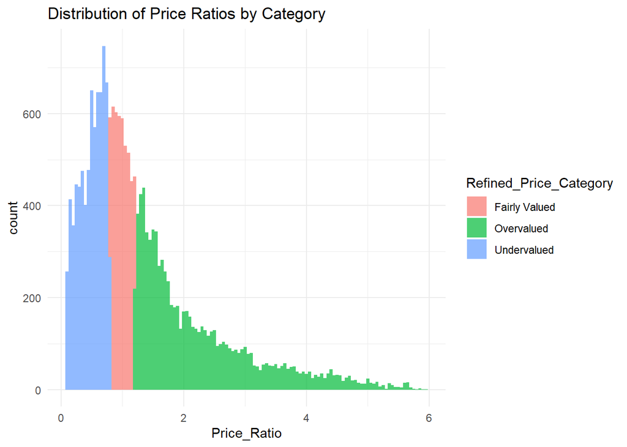

```r
ggplot(dataset_land_cleaned, aes(x = Price_Ratio, fill = Refined_Price_Category)) +
  geom_histogram(binwidth = 0.05, alpha = 0.7) +
  ggtitle("Distribution of Price Ratios by Category") +
  theme_minimal()
```

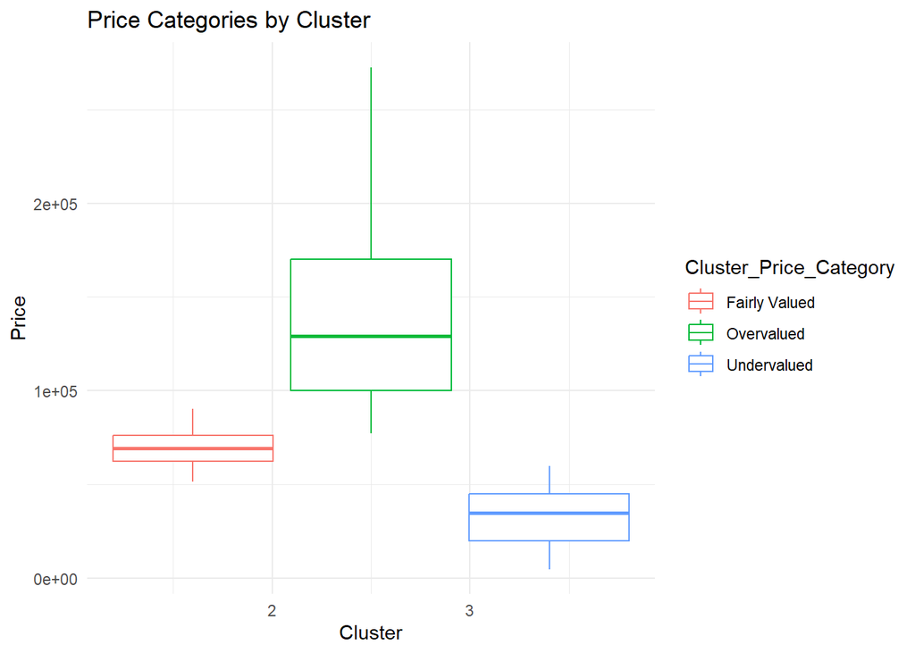

```r
ggplot(dataset_land_cleaned, aes(x = Cluster, y = Price, color = Cluster_Price_Category)) +
  geom_boxplot() +
  ggtitle("Price Categories by Cluster") +
  theme_minimal()
```

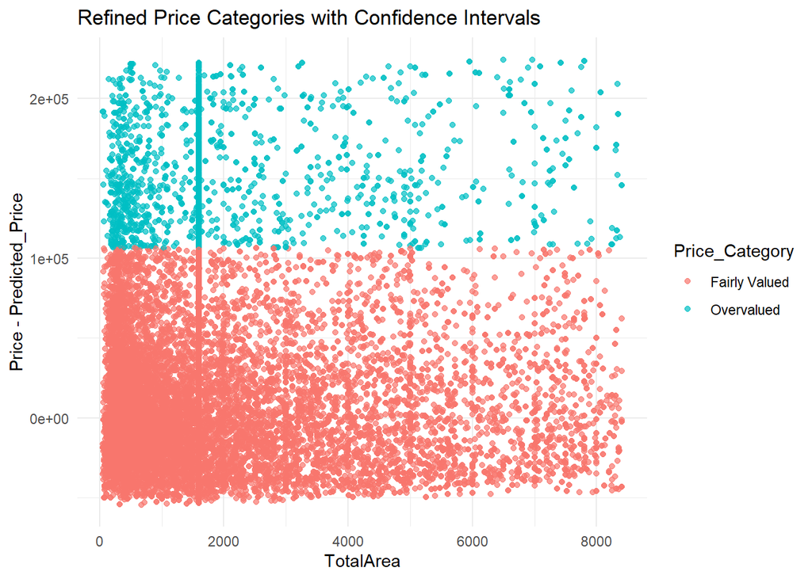

```r
ggplot(dataset_land_cleaned, aes(x = TotalArea, y = Price - Predicted_Price, color = Price_Category)) +
  geom_point(alpha = 0.7) +
  ggtitle("Refined Price Categories with Confidence Intervals") +
  theme_minimal()
```

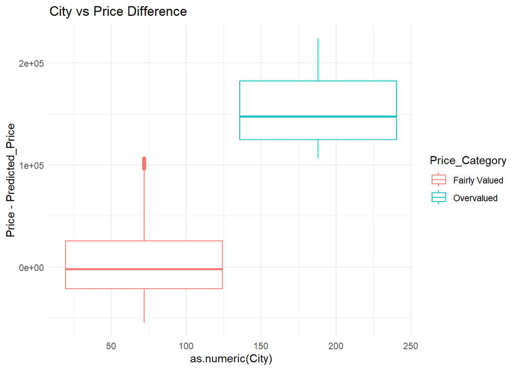

```r
ggplot(dataset_land_cleaned, aes(x = as.numeric(City), y = Price - Predicted_Price, color = Price_Category)) +
  geom_boxplot() +
  ggtitle("City vs Price Difference") +
  theme_minimal()
```

```r
# 8. Final summary of results
summary_stats <- dataset_land_cleaned %>%
  group_by(Cluster_Price_Category) %>%
  summarise(
    Avg_TotalArea = mean(TotalArea, na.rm = TRUE),
    Avg_City = mean(City, na.rm = TRUE),
    Count = n()
  )

print(summary_stats)
```

```
## # A tibble: 3 × 4
##   Cluster_Price_Category Avg_TotalArea Avg_City Count
##   <chr>                          <dbl>    <dbl> <int>
## 1 Fairly Valued                  1754.     132.  4282
## 2 Overvalued                     1944.     131.  5638
## 3 Undervalued                    1864.     129. 10705
```

**Houses**

The same proces as before is going to be used. The variables with higher correlation with price are:

- NumberOfBathrooms (0.63)
- EnergyCertificate (0.53)
- ConstructionYear (0.51)
- LivingArea (0.45)

```r
summary(dataset_house_cleaned)
```

```
##      Price            District                   City
##  Min.   :   9900   Lisboa :3019   Sintra           :  580
##  1st Qu.:  95000   Braga  :2694   Braga            :  514
##  Median : 234900   Porto  :2641   Guimarães        :  450
##  Mean   : 282568   Setúbal:1684   Vila Nova de Gaia:  434
##  3rd Qu.: 399000   Leiria :1486   Torres Vedras    :  385
##  Max.   :1015000   Coimbra:1469   Cascais          :  359
##                    (Other):8023   (Other)          :18294
##                                                                         Town
##  Charneca de Caparica e Sobreda                                           :  174
##  Fernão Ferro                                                             :  167
##  São Domingos de Rana                                                     :  164
##  Azeitão (São Lourenço e São Simão)                                       :  159
##  Palmela                                                                  :  145
##  Sintra (Santa Maria e São Miguel, São Martinho e São Pedro de Penaferrim):  126
##  (Other)                                                                  :20081
##         Type            EnergyCertificate    Parking       ConstructionYear
##  House    :21016   No Certificate:6390    Min.   :0.0000   Min.   :1900
##  Apartment:    0   E             :3163    1st Qu.:0.0000   1st Qu.:1953
##  Building :    0   F             :3003    Median :1.0000   Median :1986
##  Duplex   :    0   D             :2800    Mean   :0.8854   Mean   :1982
##  Estate   :    0   C             :1802    3rd Qu.:1.0000   3rd Qu.:2005
##  Farm     :    0   A             :1369    Max.   :3.0000   Max.   :2024
##  (Other)  :    0   (Other)       :2489
##    TotalArea       TotalRooms      LivingArea    NumberOfBathrooms
##  Min.   : 20.0   Min.   :2.000   Min.   : 25.0   Min.   :0.000
##  1st Qu.:108.0   1st Qu.:3.000   1st Qu.: 91.0   1st Qu.:1.000
##  Median :184.0   Median :3.000   Median :143.0   Median :2.000
##  Mean   :240.5   Mean   :3.253   Mean   :156.8   Mean   :2.113
##  3rd Qu.:305.0   3rd Qu.:4.000   3rd Qu.:205.0   3rd Qu.:3.000
##  Max.   :975.0   Max.   :5.000   Max.   :449.0   Max.   :6.000
##
##  CombinedElevator
##  False:20890
##  True :  126
##
##
##
##
##
```

```r
# 1. Transform EnergyCertificate to numeric.
dataset_house_cleaned <- dataset_house_cleaned %>%
  mutate(EnergyCertificate = as.numeric(EnergyCertificate))

# Transform Price using natural logarithm
dataset_house_cleaned <- dataset_house_cleaned %>%
  mutate(Log_Price = log(Price))

# Fit the model with the transformed variable
price_model <- lm(Log_Price ~ NumberOfBathrooms + LivingArea +
                  ConstructionYear + EnergyCertificate,
                  data = dataset_house_cleaned)

# 3. Prediction and calculation of residuals
dataset_house_cleaned <- dataset_house_cleaned %>%
  mutate(
    Predicted_Price = predict(price_model, dataset_house_cleaned),
    Predicted_Error = residuals(price_model), # Model errors
    Lower_Bound = Predicted_Price - 1.96 * sd(Predicted_Error), # Lower bound
    Upper_Bound = Predicted_Price + 1.96 * sd(Predicted_Error)  # Upper bound
  )

# 4. Refine definition of undervalued with confidence intervals
dataset_house_cleaned <- dataset_house_cleaned %>%
  mutate(
    Price_Category = case_when(
      Log_Price < Lower_Bound ~ "Undervalued",
      Log_Price > Upper_Bound ~ "Overvalued",
      TRUE ~ "Fairly Valued"
    )
  )

# 5. Compare actual and predicted prices with ratios
dataset_house_cleaned <- dataset_house_cleaned %>%
  mutate(
    Price_Ratio = Log_Price / Predicted_Price,
    Refined_Price_Category = case_when(
      Price_Ratio < 0.95 ~ "Undervalued",
      Price_Ratio > 1.05 ~ "Overvalued",
      TRUE ~ "Fairly Valued"
    )
  )
```

```r
# Filter records with Price less than 0
negative_price_samples <- dataset_house_cleaned %>%
  filter(Predicted_Price < 0)

# Print the filtered records
print(negative_price_samples)
```

```
##  [1] Price                  District               City
##  [4] Town                   Type                   EnergyCertificate
##  [7] Parking                ConstructionYear       TotalArea
## [10] TotalRooms             LivingArea             NumberOfBathrooms
## [13] CombinedElevator       Log_Price              Predicted_Price
## [16] Predicted_Error        Lower_Bound            Upper_Bound
## [19] Price_Category         Price_Ratio            Refined_Price_Category
## <0 rows> (o 0- extensión row.names)
```

```r
# Optional: Check how many records meet this condition
cat("Number of records with Price < 0:", nrow(negative_price_samples), "\n")
```

```
## Number of records with Price < 0: 0
```

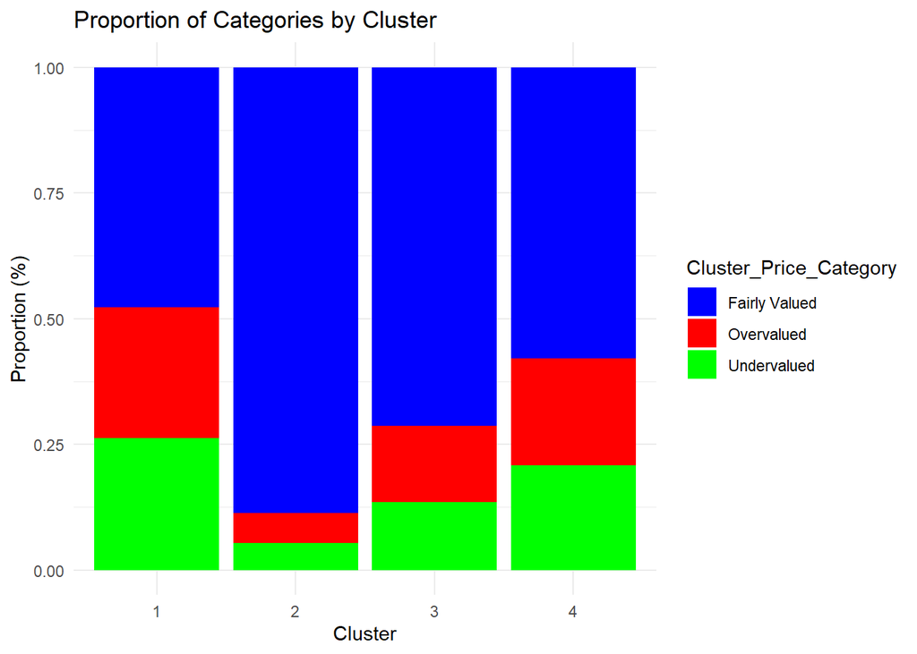

```r
# 6. Clustering analysis by similar characteristics
cluster_data <- dataset_house_cleaned %>%
  select(LivingArea, EnergyCertificate, NumberOfBathrooms, ConstructionYear) %>%
  scale()

set.seed(123)
kmeans_result <- kmeans(cluster_data, centers = 4)

# Add the clusters to the main dataset
dataset_house_cleaned <- dataset_house_cleaned %>%
  mutate(Cluster = kmeans_result$cluster)

# Calculate average prices by cluster
cluster_summary <- dataset_house_cleaned %>%
  group_by(Cluster) %>%
  summarise(
    Avg_Price = mean(Log_Price, na.rm = TRUE),
    Avg_Predicted = mean(Predicted_Price, na.rm = TRUE)
  )

# Ensure the join is correct
dataset_house_cleaned <- dataset_house_cleaned %>%
  left_join(cluster_summary, by = "Cluster")

# Validate that the necessary columns are present
if (!"Avg_Price" %in% names(dataset_house_cleaned)) {
  stop("Error: 'Avg_Price' was not correctly added to the main dataset.")
}

# Identify undervalued houses by cluster
dataset_house_cleaned <- dataset_house_cleaned %>%
  mutate(
    Cluster_Price_Category = case_when(
      Log_Price < 0.95 * Avg_Price ~ "Undervalued",
      Log_Price > 1.05 * Avg_Price ~ "Overvalued",
      TRUE ~ "Fairly Valued"
    )
  )

# 7. Visualizations
# Bar chart of the distribution of categories
# Proportion of categories within each cluster
dataset_house_cleaned %>%
  group_by(Cluster, Cluster_Price_Category) %>%
  summarise(Count = n()) %>%
  mutate(Percentage = Count / sum(Count) * 100) %>%
  ggplot(aes(x = as.factor(Cluster), y = Percentage, fill = Cluster_Price_Category)) +
  geom_bar(stat = "identity", position = "fill") +
  ggtitle("Proportion of Categories by Cluster") +
  xlab("Cluster") +
  ylab("Proportion (%)") +
  theme_minimal() +
  scale_fill_manual(values = c("blue", "red", "green"))
```

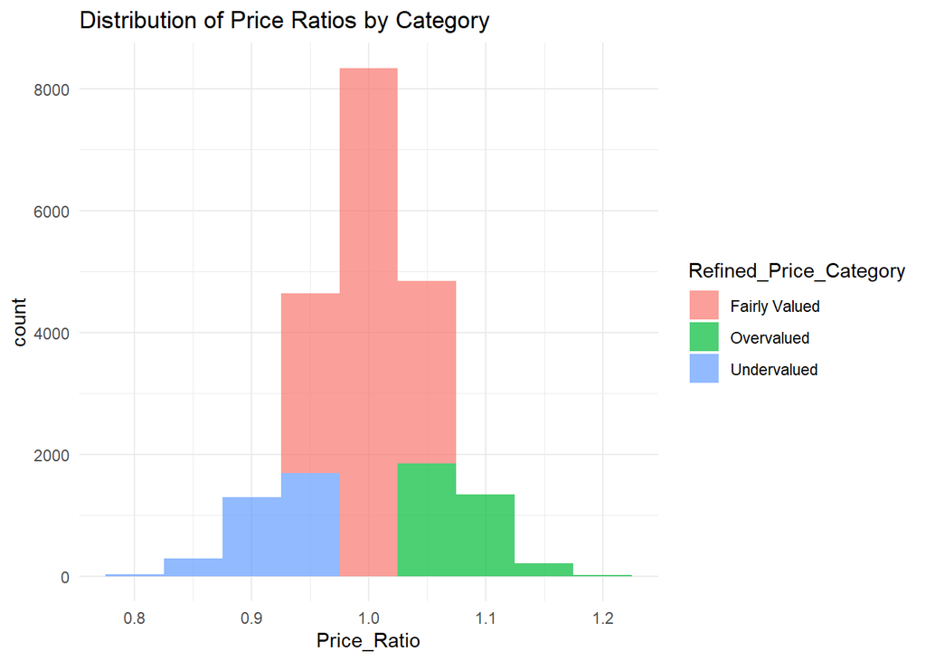

```r
ggplot(dataset_house_cleaned, aes(x = Price_Ratio, fill = Refined_Price_Category)) +
  geom_histogram(binwidth = 0.05, alpha = 0.7) +
  ggtitle("Distribution of Price Ratios by Category") +
  theme_minimal()
```

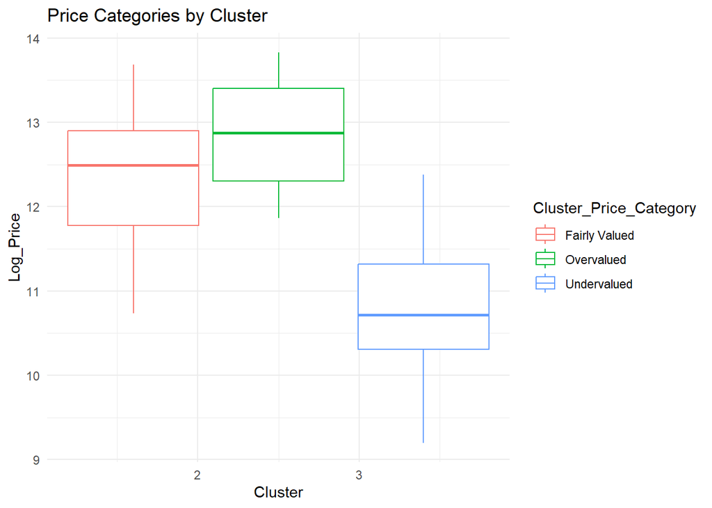

```r
ggplot(dataset_house_cleaned, aes(x = Cluster, y = Log_Price, color = Cluster_Price_Category)) +
  geom_boxplot() +
  ggtitle("Price Categories by Cluster") +
  theme_minimal()
```

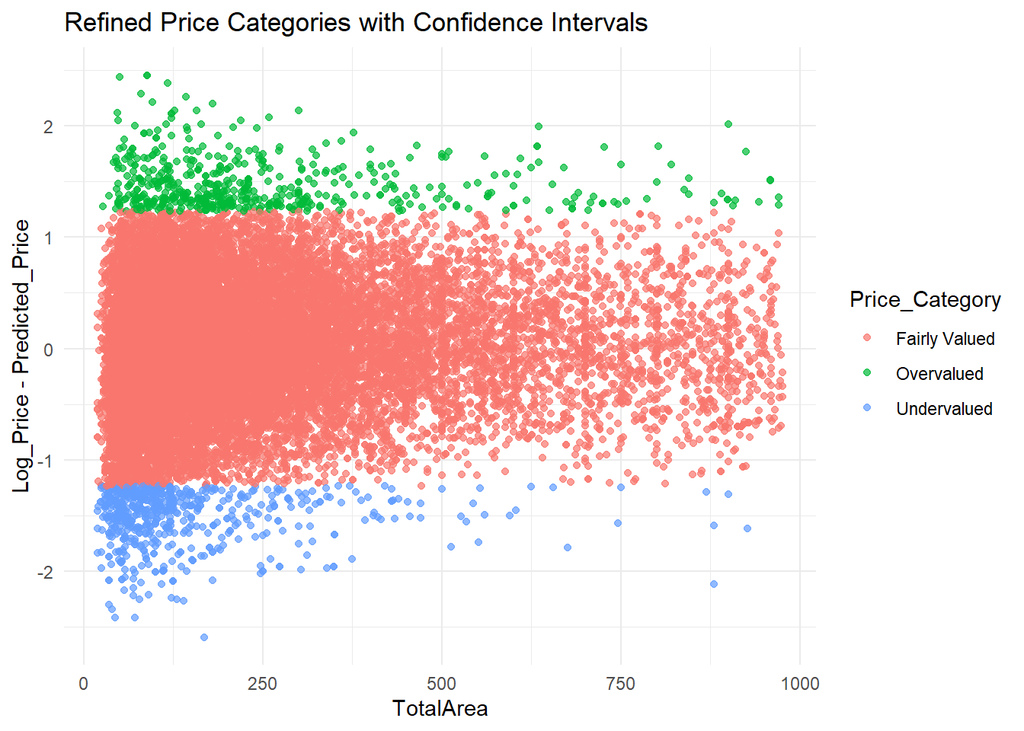

```r
ggplot(dataset_house_cleaned, aes(x = TotalArea, y = Log_Price - Predicted_Price, color = Price_Category)) +
  geom_point(alpha = 0.7) +
  ggtitle("Refined Price Categories with Confidence Intervals") +
  theme_minimal()
```

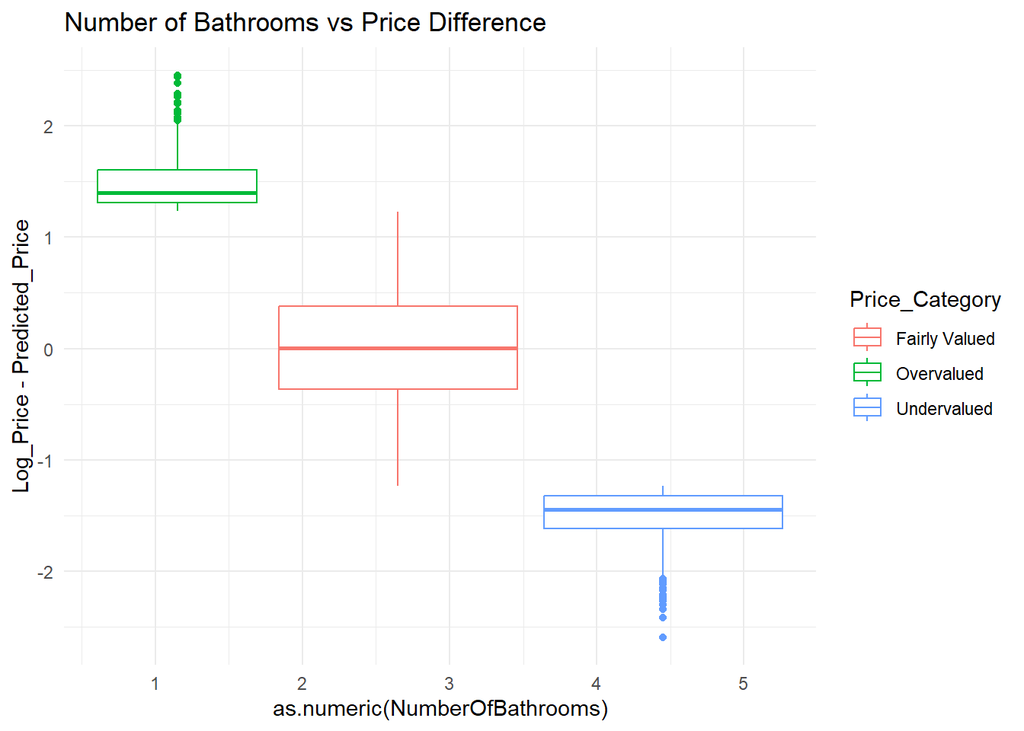

```r
ggplot(dataset_house_cleaned, aes(x = as.numeric(NumberOfBathrooms), y = Log_Price - Predicted_Price, color = Price_Category)) +
  geom_boxplot() +
  ggtitle("Number of Bathrooms vs Price Difference") +
  theme_minimal()
```

```r
# 8. Summary of final results
summary_stats <- dataset_house_cleaned %>%
  group_by(Cluster_Price_Category) %>%
  summarise(
    Avg_TotalArea = mean(TotalArea, na.rm = TRUE),
    Avg_EnergyCertificate = mean(EnergyCertificate, na.rm = TRUE),
    Avg_NumberOfBathrooms = mean(NumberOfBathrooms, na.rm = TRUE),
    Avg_ConstructionYear = mean(ConstructionYear, na.rm = TRUE),
    Count = n()
  )

print(summary_stats)
```

```
## # A tibble: 3 × 6
##   Cluster_Price_Category Avg_TotalArea Avg_EnergyCertificate
##   <chr>                          <dbl>                 <dbl>
## 1 Fairly Valued                   257.                  4.65
## 2 Overvalued                      246.                  3.76
## 3 Undervalued                     176.                  2.47
## # ℹ 3 more variables: Avg_NumberOfBathrooms <dbl>, Avg_ConstructionYear <dbl>,
## #   Count <int>
```

### Second Method

Now we are going to make another process to find overvalued and undervalued properties.

This process identifies overvalued and undervalued properties by clustering them based on their more influent characteristics (excluding price) and then comparing prices within each cluster. Here’s what happens:

1. Clustering Without Price: Properties are grouped into clusters using the attributes that hace more correlation with price in each dataset. Price is not included in clustering to avoid bias.
2. Price-Based Classification: For each cluster, the average price is calculated. Properties with prices:
- Below 80% of the cluster average are labeled undervalued.
- Above 120% of the cluster average are labeled overvalued.
- Within 80%-120% are labeled fairly valued.
3. Visualizations: Charts display the proportion of categories (undervalued, overvalued, fairly valued) and the price distribution within each cluster.

This approach separates grouping properties by features from evaluating their prices, providing an unbiased perspective on valuation.

**Apartments**

```r
# 1. Prepare data for clustering (excluding price)
cluster_data <- dataset_apartment_cleaned %>%
  select(TotalArea, LivingArea, TotalRooms, NumberOfBathrooms, ConstructionYear, Parking) %>%
  scale() # Scale the data for clustering

# 2. Perform k-means clustering
set.seed(123)
kmeans_result <- kmeans(cluster_data, centers = 4) # Use 4 clusters (adjust as needed)

# Add cluster assignments to the dataset
dataset_apartment_cleaned <- dataset_apartment_cleaned %>%
  mutate(Cluster = kmeans_result$cluster)

# 3. Calculate average price and classify properties within each cluster
dataset_apartment_cleaned <- dataset_apartment_cleaned %>%
  group_by(Cluster) %>%
  mutate(
    Avg_Price_Cluster = mean(Price, na.rm = TRUE),
    Price_Category_Cluster = case_when(
      Price < 0.8 * Avg_Price_Cluster ~ "Undervalued",  # Less than 80% of the cluster average
      Price > 1.2 * Avg_Price_Cluster ~ "Overvalued",  # Greater than 120% of the cluster average
      TRUE ~ "Fairly Valued"  # Within 80%-120% of the cluster average
    )
  ) %>%
  ungroup() # Ungroup after processing

# 4. Summarize results: Count of categories within each cluster
cluster_summary <- dataset_apartment_cleaned %>%
  group_by(Cluster, Price_Category_Cluster) %>%
  summarise(Count = n(), .groups = "drop")

# Print the cluster summary
print(cluster_summary)
```

```
## # A tibble: 12 × 3
##    Cluster Price_Category_Cluster Count
##      <int> <chr>                  <int>
##  1       1 Fairly Valued           2369
##  2       1 Overvalued              1579
##  3       1 Undervalued             3086
##  4       2 Fairly Valued           2363
##  5       2 Overvalued              1322
##  6       2 Undervalued             2216
##  7       3 Fairly Valued           2608
##  8       3 Overvalued              1891
##  9       3 Undervalued             2643
## 10       4 Fairly Valued           1686
## 11       4 Overvalued              1744
## 12       4 Undervalued             2406
```

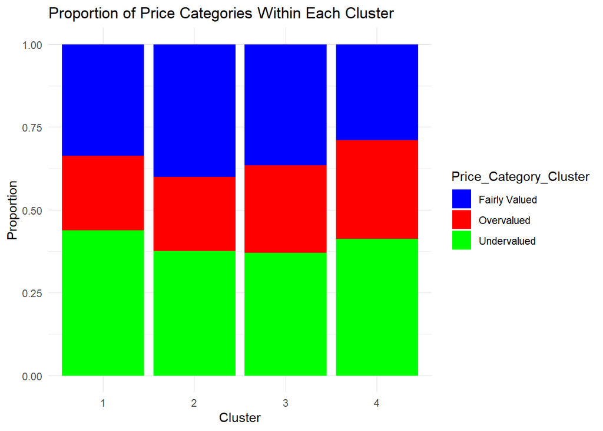

```r
# 5. Visualizations
# Proportion of categories within each cluster
ggplot(cluster_summary, aes(x = as.factor(Cluster), y = Count, fill = Price_Category_Cluster)) +
  geom_bar(stat = "identity", position = "fill") +
  ggtitle("Proportion of Price Categories Within Each Cluster") +
  xlab("Cluster") +
  ylab("Proportion") +
  theme_minimal() +
  scale_fill_manual(values = c("blue", "red", "green"))
```

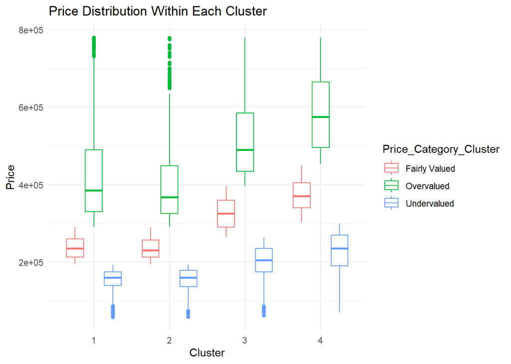

```r
# Boxplot of prices within each cluster
ggplot(dataset_apartment_cleaned, aes(x = as.factor(Cluster), y = Price, color = Price_Category_Cluster)) +
  geom_boxplot() +
  ggtitle("Price Distribution Within Each Cluster") +
  xlab("Cluster") +
  ylab("Price") +
  theme_minimal()
```

```r
# Filter for undervalued houses in the third cluster
undervalued_cluster_3 <- dataset_apartment_cleaned %>%
  filter(Cluster == 3, Price_Category_Cluster == "Undervalued")

# Summarize common characteristics
summary_undervalued_cluster_3 <- undervalued_cluster_3 %>%
  summarise(
    Avg_TotalArea = mean(TotalArea, na.rm = TRUE),
    Median_TotalArea = median(TotalArea, na.rm = TRUE),
    Avg_LivingArea = mean(LivingArea, na.rm = TRUE),
    Median_LivingArea = median(LivingArea, na.rm = TRUE),
    Avg_TotalRooms = mean(TotalRooms, na.rm = TRUE),
    Median_TotalRooms = median(TotalRooms, na.rm = TRUE),
    Avg_NumberOfBathrooms = mean(NumberOfBathrooms, na.rm = TRUE),
    Median_NumberOfBathrooms = median(NumberOfBathrooms, na.rm = TRUE),
    Avg_ConstructionYear = mean(ConstructionYear, na.rm = TRUE),
    Median_ConstructionYear = median(ConstructionYear, na.rm = TRUE),
    Avg_Parking = mean(Parking, na.rm = TRUE),
    Median_Parking = median(Parking, na.rm = TRUE)
  )

# Print the summary
print(summary_undervalued_cluster_3)
```

```
## # A tibble: 1 × 12
##   Avg_TotalArea Median_TotalArea Avg_LivingArea Median_LivingArea Avg_TotalRooms
##           <dbl>            <dbl>          <dbl>             <dbl>          <dbl>
## 1          101.              100           95.0                95           2.46
## # ℹ 7 more variables: Median_TotalRooms <dbl>, Avg_NumberOfBathrooms <dbl>,
## #   Median_NumberOfBathrooms <dbl>, Avg_ConstructionYear <dbl>,
## #   Median_ConstructionYear <dbl>, Avg_Parking <dbl>, Median_Parking <dbl>
```

```r
# Print a few undervalued samples from this cluster
cat("\nSome undervalued properties in Cluster 3:\n")
```

```
##
## Some undervalued properties in Cluster 3:
```

```r
print(head(undervalued_cluster_3, 50))  # Adjust the number of rows to display as needed
```

```
## # A tibble: 50 × 27
##     Price District City              Town  Type  EnergyCertificate Floor Parking
##     <dbl> <fct>    <fct>             <fct> <fct> <fct>             <fct>   <dbl>
##  1 250000 Faro     São Brás de Alpo… São … Apar… A+                2nd …       1
##  2 223000 Faro     São Brás de Alpo… São … Apar… A+                Grou…       1
##  3 228000 Faro     São Brás de Alpo… São … Apar… A+                Grou…       1
##  4 250000 Faro     São Brás de Alpo… São … Apar… A+                1st …       1
##  5 159900 Faro     Olhão             Olhão Apar… E                 2nd …       0
##  6 159900 Faro     Olhão             Olhão Apar… C                 1st …       0
##  7 260000 Faro     Aljezur           Odec… Apar… C                 2nd …       1
##  8 262500 Faro     Portimão          Port… Apar… A                 Grou…       1
##  9 242500 Faro     Portimão          Port… Apar… A                 Grou…       0
## 10 220000 Faro     Albufeira         Albu… Apar… C                 3rd …       0
## # ℹ 40 more rows
## # ℹ 19 more variables: ConstructionYear <dbl>, TotalArea <dbl>,
## #   TotalRooms <dbl>, LivingArea <dbl>, NumberOfBathrooms <dbl>,
## #   CombinedElevator <fct>, Predicted_Price <dbl>, Predicted_Error <dbl>,
## #   Lower_Bound <dbl>, Upper_Bound <dbl>, Price_Category <chr>,
## #   Price_Ratio <dbl>, Refined_Price_Category <chr>, Cluster <int>,
## #   Avg_Price <dbl>, Avg_Predicted <dbl>, Cluster_Price_Category <chr>, …
```

**Lands**

```r
summary(dataset_land_cleaned)
```

```
##      Price            District         City
##  Min.   :  4900   Porto   :3194   Min.   :  1.0
##  1st Qu.: 32500   Lisboa  :2300   1st Qu.: 69.0
##  Median : 55000   Braga   :2127   Median :120.0
##  Mean   : 70482   Aveiro  :1988   Mean   :130.2
##  3rd Qu.: 90000   Santarém:1848   3rd Qu.:202.0
##  Max.   :272500   Leiria  :1804   Max.   :259.0
##                   (Other) :7364
##                              Town              Type
##  São João das Lampas e Terrugem:  239   Land     :20625
##  Pombal                        :  143   Apartment:    0
##  Palmela                       :  120   Building :    0
##  Castelo (Sesimbra)            :  116   Duplex   :    0
##  Charneca de Caparica e Sobreda:  113   Estate   :    0
##  Quinta do Anjo                :  113   Farm     :    0
##  (Other)                       :19781   (Other)  :    0
##       EnergyCertificate    Parking    TotalArea    NumberOfBathrooms
##  No Certificate:20526   Min.   :0   Min.   :  56   Min.   :0
##  A+            :   27   1st Qu.:0   1st Qu.: 600   1st Qu.:0
##  G             :   26   Median :0   Median :1600   Median :0
##  A             :   20   Mean   :0   Mean   :1863   Mean   :0
##  B             :   11   3rd Qu.:0   3rd Qu.:2000   3rd Qu.:0
##  E             :    6   Max.   :0   Max.   :8400   Max.   :0
##  (Other)       :    9
##  CombinedElevator Predicted_Price_Poly Predicted_Price_Expo
##  False:20597      Min.   :60559        Min.   :43004
##  True :   28      1st Qu.:67531        1st Qu.:49815
##                   Median :71505        Median :52423
##                   Mean   :70482        Mean   :52692
##                   3rd Qu.:73881        3rd Qu.:55580
##                   Max.   :81820        Max.   :59973
##
##  Predicted_Price_Power Predicted_Price Predicted_Error   Lower_Bound
##  Min.   :61925         Min.   :43103   Min.   :-54355   Min.   :-63331
##  1st Qu.:67207         1st Qu.:49831   1st Qu.:-19404   1st Qu.:-56603
##  Median :70260         Median :52380   Median :  1892   Median :-54054
##  Mean   :70482         Mean   :52690   Mean   : 17792   Mean   :-53744
##  3rd Qu.:74002         3rd Qu.:55568   3rd Qu.: 36980   3rd Qu.:-50866
##  Max.   :79978         Max.   :59924   Max.   :224444   Max.   :-46510
##
##   Upper_Bound     Price_Category      Price_Ratio      Refined_Price_Category
##  Min.   :149537   Length:20625       Min.   :0.08424   Length:20625
##  1st Qu.:156265   Class :character   1st Qu.:0.62557   Class :character
##  Median :158815   Mode  :character   Median :1.03557   Mode  :character
##  Mean   :159125                      Mean   :1.33981
##  3rd Qu.:162003                      3rd Qu.:1.70459
##  Max.   :166358                      Max.   :5.92683
##
##     Cluster        Avg_Price     Avg_Predicted   Cluster_Price_Category
##  Min.   :1.000   Min.   :64314   Min.   :49460   Length:20625
##  1st Qu.:2.000   1st Qu.:64314   1st Qu.:49460   Class :character
##  Median :3.000   Median :71588   Median :53312   Mode  :character
##  Mean   :2.784   Mean   :70482   Mean   :52690
##  3rd Qu.:4.000   3rd Qu.:75522   3rd Qu.:57271
##  Max.   :4.000   Max.   :75522   Max.   :57271
##
```

```r
# 1. Transform City and District to numeric without removing the original columns
dataset_land_cleaned <- dataset_land_cleaned %>%
  mutate(
    CityNum = as.numeric(City),  # Convert cities to numeric
    DistrictNum = as.numeric(District)  # Convert districts to numeric
  )

# 2. Prepare data for clustering (excluding price)
cluster_data <- dataset_land_cleaned %>%
  select(TotalArea, DistrictNum, CityNum) %>%
  scale() # Scale the data for clustering

# 3. Perform k-means clustering
set.seed(123)
kmeans_result <- kmeans(cluster_data, centers = 4)  # Use 4 clusters, you can adjust the number

# 4. Add cluster assignments to the dataset
dataset_land_cleaned <- dataset_land_cleaned %>%
  mutate(Cluster = kmeans_result$cluster)

# 5. Calculate average price and classify properties within each cluster
dataset_land_cleaned <- dataset_land_cleaned %>%
  group_by(Cluster) %>%
  mutate(
    Avg_Price_Cluster = mean(Price, na.rm = TRUE),
    Price_Category_Cluster = case_when(
      Price < 0.8 * Avg_Price_Cluster ~ "Undervalued",  # Less than 80% of the cluster average
      Price > 1.2 * Avg_Price_Cluster ~ "Overvalued",  # More than 120% of the cluster average
      TRUE ~ "Fairly Valued"  # Within 80%-120% of the cluster average
    )
  ) %>%
  ungroup()  # Ungroup after processing

# 6. Summarize results: Count of categories within each cluster
cluster_summary <- dataset_land_cleaned %>%
  group_by(Cluster, Price_Category_Cluster) %>%
  summarise(Count = n(), .groups = "drop")

# Print the cluster summary
print(cluster_summary)
```

```
## # A tibble: 12 × 3
##    Cluster Price_Category_Cluster Count
##      <int> <chr>                  <int>
##  1       1 Fairly Valued            457
##  2       1 Overvalued               748
##  3       1 Undervalued             1342
##  4       2 Fairly Valued           1264
##  5       2 Overvalued              1690
##  6       2 Undervalued             2929
##  7       3 Fairly Valued           1436
##  8       3 Overvalued              1865
##  9       3 Undervalued             3693
## 10       4 Fairly Valued           1021
## 11       4 Overvalued              1446
## 12       4 Undervalued             2734
```

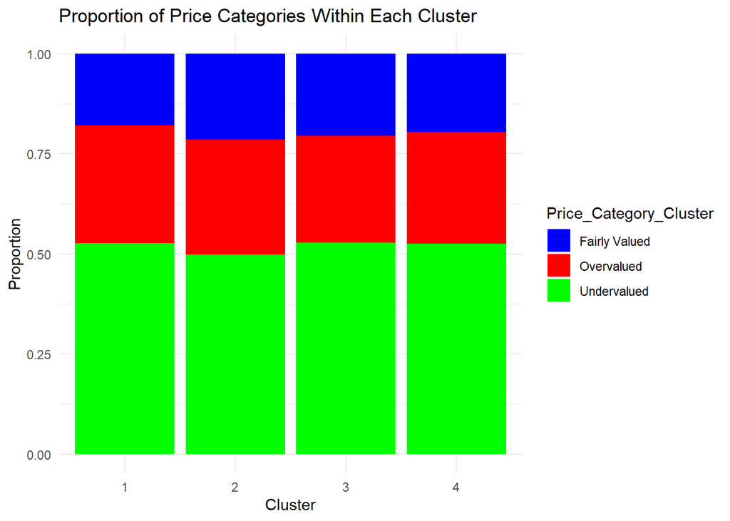

```r
# 7. Visualization: Proportion of categories within each cluster
ggplot(cluster_summary, aes(x = as.factor(Cluster), y = Count, fill = Price_Category_Cluster)) +
  geom_bar(stat = "identity", position = "fill") +
  ggtitle("Proportion of Price Categories Within Each Cluster") +
  xlab("Cluster") +
  ylab("Proportion") +
  theme_minimal() +
  scale_fill_manual(values = c("blue", "red", "green"))
```

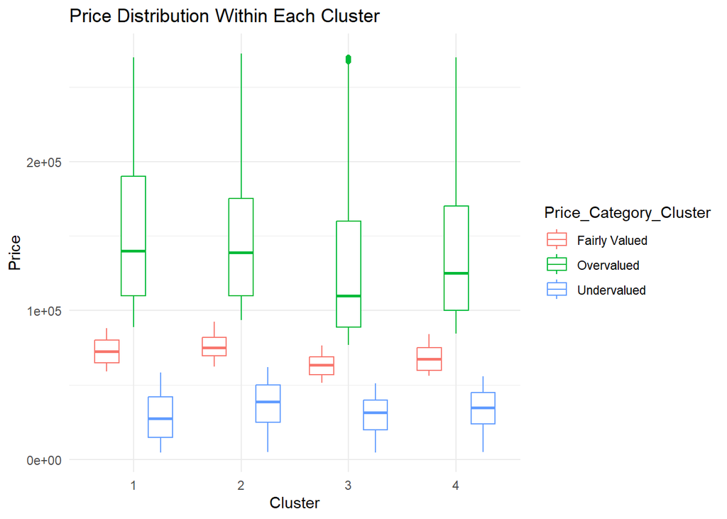

```r
# 8. Boxplot of prices within each cluster
ggplot(dataset_land_cleaned, aes(x = as.factor(Cluster), y = Price, color = Price_Category_Cluster)) +
  geom_boxplot() +
  ggtitle("Price Distribution Within Each Cluster") +
  xlab("Cluster") +
  ylab("Price") +
  theme_minimal()
```

```r
# 9. Filter undervalued properties in the second cluster
undervalued_cluster_2 <- dataset_land_cleaned %>%
  filter(Cluster == 2, Price_Category_Cluster == "Undervalued")

# 10. Summarize common characteristics of undervalued properties
summary_undervalued_cluster_2 <- undervalued_cluster_2 %>%
  summarise(
    Avg_TotalArea = mean(TotalArea, na.rm = TRUE),
    Median_TotalArea = median(TotalArea, na.rm = TRUE),
    Avg_District = mean(DistrictNum, na.rm = TRUE),
    Median_District = median(DistrictNum, na.rm = TRUE),
    Avg_City = mean(CityNum, na.rm = TRUE),
    Median_City = median(CityNum, na.rm = TRUE)
  )

# Print the summary
print(summary_undervalued_cluster_2)
```

```
## # A tibble: 1 × 6
##   Avg_TotalArea Median_TotalArea Avg_District Median_District Avg_City
##           <dbl>            <dbl>        <dbl>           <dbl>    <dbl>
## 1         1269.             1440         18.4              19     203.
## # ℹ 1 more variable: Median_City <dbl>
```

```r
# 11. Print some undervalued properties from cluster 2
cat("\nSome undervalued properties in Cluster 2:\n")
```

```
##
## Some undervalued properties in Cluster 2:
```

```r
print(head(undervalued_cluster_2, 50))  # Adjust the number of rows to display as needed
```

```
## # A tibble: 50 × 28
##    Price District  City Town           Type  EnergyCertificate Parking TotalArea
##    <dbl> <fct>    <dbl> <fct>          <fct> <fct>               <dbl>     <dbl>
##  1 50000 Faro       240 Budens         Land  No Certificate          0       384
##  2 50000 Faro       240 Budens         Land  No Certificate          0       384
##  3 15000 Faro       213 São Bartolome… Land  No Certificate          0      2040
##  4 50000 Faro       240 Budens         Land  No Certificate          0       384
##  5 17500 Faro       213 São Bartolome… Land  No Certificate          0      1720
##  6 20000 Faro       213 São Bartolome… Land  No Certificate          0      2080
##  7 55000 Faro       240 Vila do Bispo… Land  No Certificate          0      3250
##  8 50000 Faro       240 Vila do Bispo… Land  No Certificate          0      1500
##  9 49000 Faro       203 São Brás de A… Land  No Certificate          0       380
## 10 15000 Faro       213 São Bartolome… Land  No Certificate          0      1720
## # ℹ 40 more rows
## # ℹ 20 more variables: NumberOfBathrooms <dbl>, CombinedElevator <fct>,
## #   Predicted_Price_Poly <dbl>, Predicted_Price_Expo <dbl>,
## #   Predicted_Price_Power <dbl>, Predicted_Price <dbl>, Predicted_Error <dbl>,
## #   Lower_Bound <dbl>, Upper_Bound <dbl>, Price_Category <chr>,
## #   Price_Ratio <dbl>, Refined_Price_Category <chr>, Cluster <int>,
## #   Avg_Price <dbl>, Avg_Predicted <dbl>, Cluster_Price_Category <chr>, …
```

**House**

```r
# 1. Transformamos EnergyCertificate a numerico.
dataset_house_cleaned <- dataset_house_cleaned %>%
  mutate(EnergyCertificate = as.numeric(EnergyCertificate))

# 1. Prepare data for clustering (excluding price)
cluster_data <- dataset_house_cleaned %>%
  select(LivingArea, ConstructionYear, EnergyCertificate, NumberOfBathrooms) %>%
  scale() # Scale the data for clustering

# 2. Perform k-means clustering
set.seed(123)
kmeans_result <- kmeans(cluster_data, centers = 4) # Use 4 clusters (adjust as needed)

# Add cluster assignments to the dataset
dataset_house_cleaned <- dataset_house_cleaned %>%
  mutate(Cluster = kmeans_result$cluster)

# 3. Calculate average price and classify properties within each cluster
dataset_house_cleaned <- dataset_house_cleaned %>%
  group_by(Cluster) %>%
  mutate(
    Avg_Price_Cluster = mean(Price, na.rm = TRUE),
    Price_Category_Cluster = case_when(
      Price < 0.8 * Avg_Price_Cluster ~ "Undervalued",  # Less than 80% of the cluster average
      Price > 1.2 * Avg_Price_Cluster ~ "Overvalued",  # Greater than 120% of the cluster average
      TRUE ~ "Fairly Valued"  # Within 80%-120% of the cluster average
    )
  ) %>%
  ungroup() # Ungroup after processing

# 4. Summarize results: Count of categories within each cluster
cluster_summary <- dataset_house_cleaned %>%
  group_by(Cluster, Price_Category_Cluster) %>%
  summarise(Count = n(), .groups = "drop")

# Print the cluster summary
print(cluster_summary)
```

```
## # A tibble: 12 × 3
##    Cluster Price_Category_Cluster Count
##      <int> <chr>                  <int>
##  1       1 Fairly Valued            971
##  2       1 Overvalued              1871
##  3       1 Undervalued             3906
##  4       2 Fairly Valued           1627
##  5       2 Overvalued              1276
##  6       2 Undervalued             1771
##  7       3 Fairly Valued           1011
##  8       3 Overvalued               959
##  9       3 Undervalued             1320
## 10       4 Fairly Valued           1549
## 11       4 Overvalued              1861
## 12       4 Undervalued             2894
```

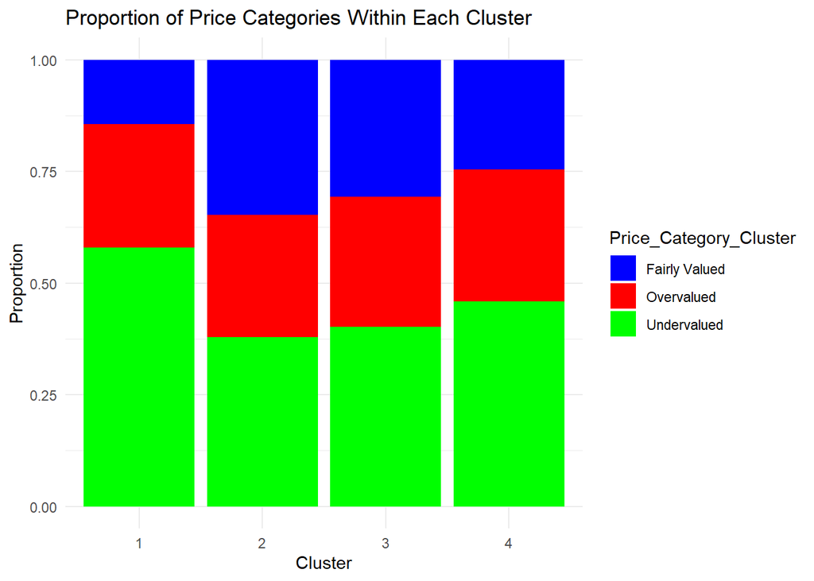

```r
# 5. Visualizations
# Proportion of categories within each cluster
ggplot(cluster_summary, aes(x = as.factor(Cluster), y = Count, fill = Price_Category_Cluster)) +
  geom_bar(stat = "identity", position = "fill") +
  ggtitle("Proportion of Price Categories Within Each Cluster") +
  xlab("Cluster") +
  ylab("Proportion") +
  theme_minimal() +
  scale_fill_manual(values = c("blue", "red", "green"))
```

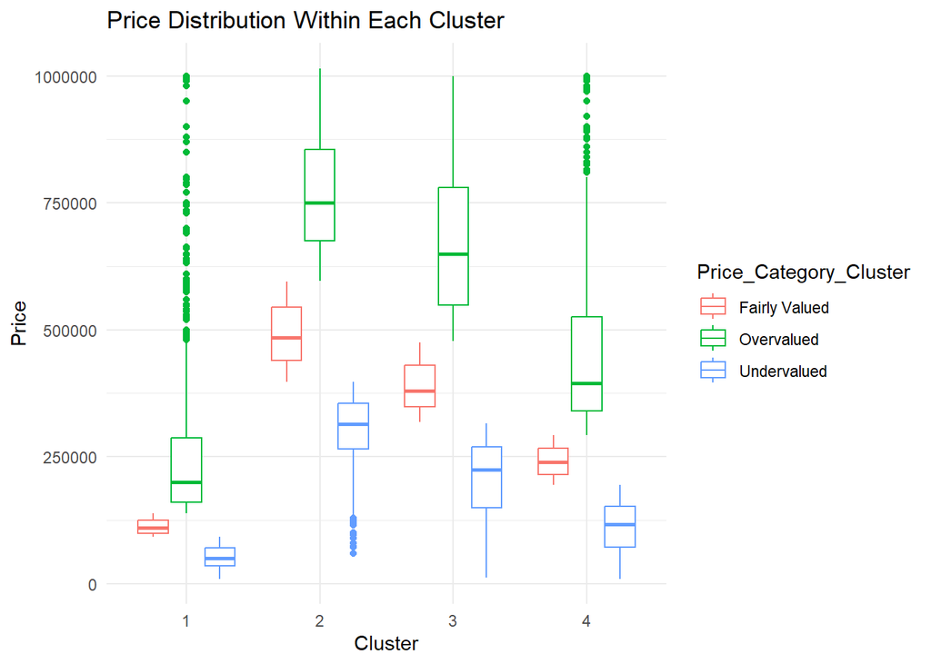

```r
# Boxplot of prices within each cluster
ggplot(dataset_house_cleaned, aes(x = as.factor(Cluster), y = Price, color = Price_Category_Cluster)) +
  geom_boxplot() +
  ggtitle("Price Distribution Within Each Cluster") +
  xlab("Cluster") +
  ylab("Price") +
  theme_minimal()
```

```r
# Filter for undervalued houses in the second cluster
undervalued_cluster_2 <- dataset_house_cleaned %>%
  filter(Cluster == 2, Price_Category_Cluster == "Undervalued")

# Summarize common characteristics
summary_undervalued_cluster_2 <- undervalued_cluster_2 %>%
  summarise(
    Avg_LivingArea = mean(LivingArea, na.rm = TRUE),
    Median_LivingArea = median(LivingArea, na.rm = TRUE),
    Avg_ConstructionYear = mean(ConstructionYear, na.rm = TRUE),
    Median_ConstructionYear = median(ConstructionYear, na.rm = TRUE),
    Avg_EnergyCertificate = mean(EnergyCertificate, na.rm = TRUE),
    Median_EnergyCertificate = median(EnergyCertificate, na.rm = TRUE),
    Avg_NumberOfBathrooms = mean(NumberOfBathrooms, na.rm = TRUE),
    Median_NumberOfBathrooms = median(NumberOfBathrooms, na.rm = TRUE)
  )

# Print the summary
print(summary_undervalued_cluster_2)
```

```
## # A tibble: 1 × 8
##   Avg_LivingArea Median_LivingArea Avg_ConstructionYear Median_ConstructionYear
##            <dbl>             <dbl>                <dbl>                   <dbl>
## 1           183.               176                2006.                    2007
## # ℹ 4 more variables: Avg_EnergyCertificate <dbl>,
## #   Median_EnergyCertificate <dbl>, Avg_NumberOfBathrooms <dbl>,
## #   Median_NumberOfBathrooms <dbl>
```

```r
# Print a few undervalued samples from this cluster
cat("\nSome undervalued properties in Cluster 2:\n")
```

```
##
## Some undervalued properties in Cluster 2:
```

```r
print(head(undervalued_cluster_2, 50))  # Adjust the number of rows to display as needed
```

```
## # A tibble: 50 × 27
##     Price District City   Town  Type  EnergyCertificate Parking ConstructionYear
##     <dbl> <fct>    <fct>  <fct> <fct>             <dbl>   <dbl>            <dbl>
##  1 387000 Faro     Lagos  Odiá… House                10       0             1986
##  2 350000 Faro     Faro   Faro… House                 9       0             1950
##  3 289900 Faro     Silves São … House                 5       2             2015
##  4 355000 Faro     Porti… Port… House                 8       1             1992
##  5 397000 Faro     Tavira Conc… House                 6       1             2008
##  6 375000 Faro     Porti… Alvor House                 7       2             2007
##  7 244000 Guarda   Seia   Seia… House                 9       2             1986
##  8 295000 Guarda   Seia   Seia… House                 9       0             2005
##  9 184000 Guarda   Seia   Sand… House                 7       2             1982
## 10 235000 Guarda   Pinhel Agre… House                10       0             1949
## # ℹ 40 more rows
## # ℹ 19 more variables: TotalArea <dbl>, TotalRooms <dbl>, LivingArea <dbl>,
## #   NumberOfBathrooms <dbl>, CombinedElevator <fct>, Log_Price <dbl>,
## #   Predicted_Price <dbl>, Predicted_Error <dbl>, Lower_Bound <dbl>,
## #   Upper_Bound <dbl>, Price_Category <chr>, Price_Ratio <dbl>,
## #   Refined_Price_Category <chr>, Cluster <int>, Avg_Price <dbl>,
## #   Avg_Predicted <dbl>, Cluster_Price_Category <chr>, …
```

## Third Subquestion

**Which areas have the highest concentration of undervalued properties?**

```r
undervalued_apartments <- dataset_apartment_cleaned %>%
  filter(Price_Category_Cluster == "Undervalued")

# Count the total properties by district
total_apartment_district <- dataset_apartment_cleaned %>%
  group_by(District) %>%
  summarise(Total = n(), .groups = "drop")

# Count the undervalued properties by district
undervalued_apartments_district <- undervalued_apartments %>%
  group_by(District) %>%
  summarise(Undervalued_Count = n(), .groups = "drop")

# Combine the data and calculate the percentage
apartment_district_analysis <- total_apartment_district %>%
  left_join(undervalued_apartments_district, by = "District") %>%
  mutate(
    Undervalued_Count = ifelse(is.na(Undervalued_Count), 0, Undervalued_Count), # Replace NAs with 0
    Percentage_Undervalued = (Undervalued_Count / Total) * 100
  ) %>%
  arrange(desc(Percentage_Undervalued))

# Display the results
print(apartment_district_analysis)
```

```
## # A tibble: 19 × 4
##    District            Total Undervalued_Count Percentage_Undervalued
##    <fct>               <int>             <int>                  <dbl>
##  1 Bragança              135               135                  100
##  2 Guarda                 33                33                  100
##  3 Ilha de Porto Santo     1                 1                  100
##  4 Portalegre             90                90                  100
##  5 Castelo Branco        273               272                   99.6
##  6 Vila Real             117               116                   99.1
##  7 Santarém              595               535                   89.9
##  8 Beja                   41                32                   78.0
##  9 Évora                 107                76                   71.0
## 10 Braga                1686              1162                   68.9
## 11 Viana do Castelo      500               342                   68.4
## 12 Leiria                939               612                   65.2
## 13 Coimbra              1124               606                   53.9
## 14 Ilha de São Miguel      2                 1                   50
## 15 Aveiro               1183               543                   45.9
## 16 Porto                5487              2234                   40.7
## 17 Setúbal              3171              1257                   39.6
## 18 Lisboa               8282              1924                   23.2
## 19 Faro                 2147               380                   17.7
```

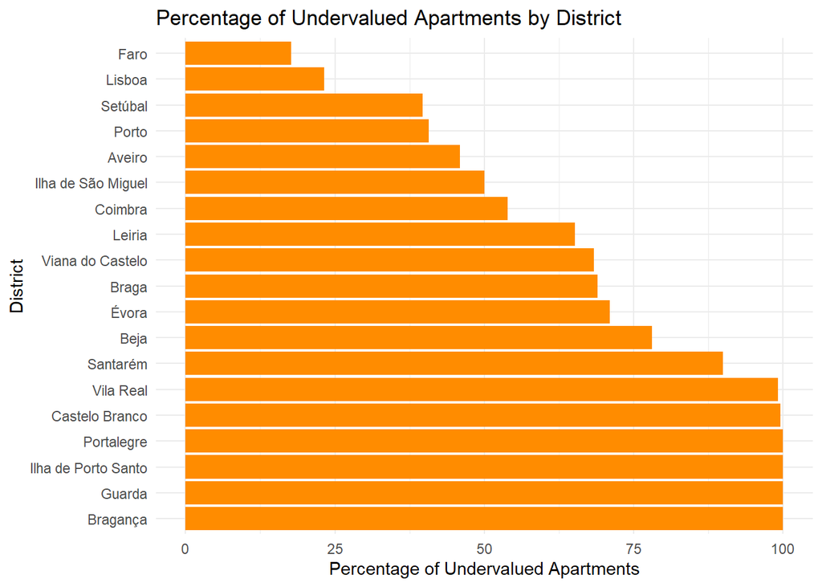

```r
# Visualization of percentages by district
ggplot(apartment_district_analysis, aes(x = reorder(District, -Percentage_Undervalued), y = Percentage_Undervalued)) +
  geom_bar(stat = "identity", fill = "darkorange") +
  coord_flip() +
  ggtitle("Percentage of Undervalued Apartments by District") +
  xlab("District") +
  ylab("Percentage of Undervalued Apartments") +
  theme_minimal()
```

```r
undervalued_lands <- dataset_land_cleaned %>%
  filter(Price_Category_Cluster == "Undervalued")

# Count the total properties by district
total_land_district <- dataset_land_cleaned %>%
  group_by(District) %>%
  summarise(Total = n(), .groups = "drop")

# Count the undervalued properties by district
undervalued_land_district <- undervalued_lands %>%
  group_by(District) %>%
  summarise(Undervalued_Count = n(), .groups = "drop")

# Combine the data and calculate the percentage
land_district_analysis <- total_land_district %>%
  left_join(undervalued_land_district, by = "District") %>%
  mutate(
    Undervalued_Count = ifelse(is.na(Undervalued_Count), 0, Undervalued_Count), # Replace NAs with 0
    Percentage_Undervalued = (Undervalued_Count / Total) * 100
  ) %>%
  arrange(desc(Percentage_Undervalued))

# Display the results
print(land_district_analysis)
```

```
## # A tibble: 23 × 4
##    District            Total Undervalued_Count Percentage_Undervalued
##    <fct>               <int>             <dbl>                  <dbl>
##  1 Viseu                  15                13                   86.7
##  2 Castelo Branco       1039               875                   84.2
##  3 Portalegre            220               180                   81.8
##  4 Guarda                248               186                   75
##  5 Santarém             1848              1319                   71.4
##  6 Viana do Castelo     1023               705                   68.9
##  7 Leiria               1804              1125                   62.4
##  8 Vila Real             530               330                   62.3
##  9 Ilha de Santa Maria    75                46                   61.3
## 10 Coimbra              1739              1045                   60.1
## # ℹ 13 more rows
```

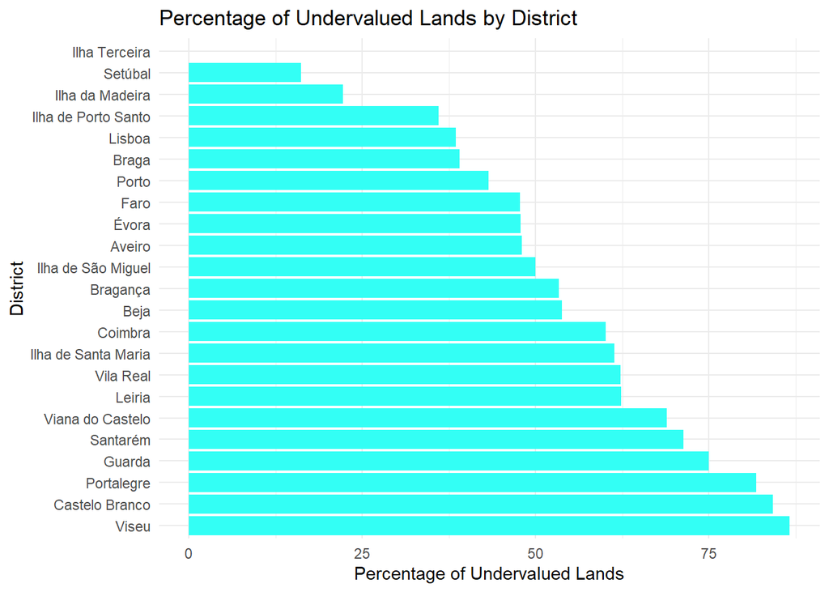

```r
# Visualization of percentages by district
ggplot(land_district_analysis, aes(x = reorder(District, -Percentage_Undervalued), y = Percentage_Undervalued)) +
  geom_bar(stat = "identity", fill = "#33FFF5") +
  coord_flip() +
  ggtitle("Percentage of Undervalued Lands by District") +
  xlab("District") +
  ylab("Percentage of Undervalued Lands") +
  theme_minimal()
```

```r
undervalued_houses <- dataset_house_cleaned %>%
  filter(Price_Category_Cluster == "Undervalued")

# Count the total properties by district
total_house_district <- dataset_house_cleaned %>%
  group_by(District) %>%
  summarise(Total = n(), .groups = "drop")

# Count the undervalued properties by district
undervalued_house_district <- undervalued_houses %>%
  group_by(District) %>%
  summarise(Undervalued_Count = n(), .groups = "drop")

# Combine the data and calculate the percentage
house_district_analysis <- total_house_district %>%
  left_join(undervalued_house_district, by = "District") %>%
  mutate(
    Undervalued_Count = ifelse(is.na(Undervalued_Count), 0, Undervalued_Count), # Replace NAs with 0
    Percentage_Undervalued = (Undervalued_Count / Total) * 100
  ) %>%
  arrange(desc(Percentage_Undervalued))

# Display the results
print(house_district_analysis)
```

```
## # A tibble: 23 × 4
##    District         Total Undervalued_Count Percentage_Undervalued
##    <fct>            <int>             <dbl>                  <dbl>
##  1 Viseu               14                14                  100
##  2 Guarda             466               421                   90.3
##  3 Bragança           352               317                   90.1
##  4 Portalegre         586               508                   86.7
##  5 Castelo Branco     947               819                   86.5
##  6 Vila Real          528               429                   81.2
##  7 Coimbra           1469              1086                   73.9
##  8 Beja               336               228                   67.9
##  9 Santarém          1236               772                   62.5
## 10 Viana do Castelo   701               424                   60.5
## # ℹ 13 more rows
```

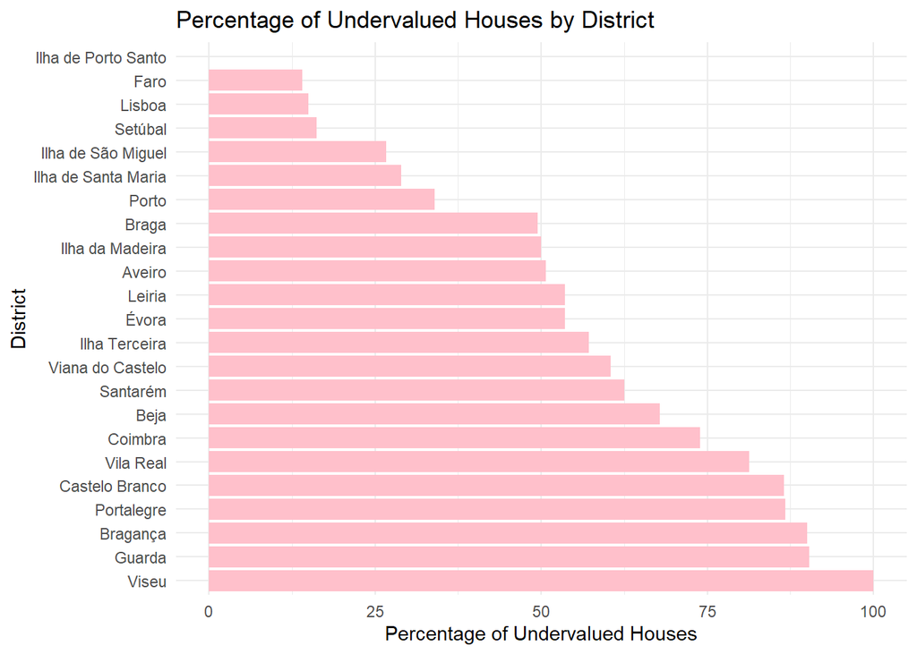

```r
# Visualization of percentages by district
ggplot(house_district_analysis, aes(x = reorder(District, -Percentage_Undervalued), y = Percentage_Undervalued)) +
  geom_bar(stat = "identity", fill = "pink") +
  coord_flip() +
  ggtitle("Percentage of Undervalued Houses by District") +
  xlab("District") +
  ylab("Percentage of Undervalued Houses") +
  theme_minimal()
```

**- Apartments**

Districts such as Bragança, Guarda, Ilha de Porto Santo, and Portalegre have 100% of their apartments classified as undervalued, while large districts like Lisboa have a much lower proportion (23.2%).

**- Lands**

The districts with the highest proportion of undervalued lands are Viseu (86.7%), Castelo Branco (84.2%), and Portalegre (81.8%). Districts such as Lisboa and Faro show relatively low percentages.

**- Houses**

In the analysis of houses, the districts with the highest concentration of undervalued properties are Viseu (100%), Guarda (90.3%), and Bragança (90.1%). Lisboa and Faro, once again, show low percentages (15.0% and 14.0%, respectively).

**General Conclusion on Undervalued Properties**

**1. Districts with the highest concentration of undervalued properties**

**2. Districts with the lowest concentration of undervalued properties**

Large and economically active districts, such as:

- Lisboa and Faro, consistently show a lower proportion of undervalued properties across all categories.

This suggests that properties in densely urbanized and tourist-heavy areas tend to align more closely with their estimated market values, likely due to higher competition and more accurate price assessments.

**3. Geographical patterns of undervaluation**

Rural or less populated districts:

- Districts like Portalegre, Vila Real, and Castelo Branco tend to show high percentages of undervalued properties.
- This could be due to lower demand in these areas, leading to market prices that do not fully reflect the properties’ potential value.

Urban or tourist regions:

- Areas such as Lisboa, Setúbal, and Porto show lower percentages of undervalued properties, indicating tighter real estate markets aligned with economic dynamics.

**4. General implications**

Consolidated markets:

- Districts like Lisboa and Faro reflect more competitive markets, where properties are less likely to be undervalued. This may indicate higher economic development and stability in real estate prices.